# MSDS Statistical Learning Project 12/14/2020

Christopher Rabeony, Matthew Dula, Eric Cartaya

12/14/2020

#### Import our Library

```r
library(corrplot) # correlation detection
library(corrgram) # correlation plot
library(MASS) # stepwise function for model selection
library(caret) # confusion matrix
library(rpart) # desicion tree
library(rpart.plot) # descision tree plot
library(randomForest) # random forest
library(ROCR) # ploting ROC curve
library(pROC) # Function to calculate the ROC
library(e1071) # Performing Support Vector Machine
library(gbm) # Gradient Boosting
library(class) # K- Nearest Neighbors
```

## Heart Disease

Cardiovascular disease includes a number of conditions affecting the structures or function of the heart, including coronary artery disease and vascular (blood vessel) disease. Also known as Heart disease, it is by far the leading cause of death in the United States. Coronary artery disease is the narrowing of the arteries supplying blood to the heart. It has caused about one million heart attacks each year. Even more worrisome, hundreds of thousands people with heart attacks will die before even reaching the hospital.

Our goal is to investigate what factors lead to heart disease. We will use the dataset for this project which is available on UCI machine learning repository. This project, will run statistical testings and regression/classification models using data from the Cleveland heart disease dataset to asses what factors significantly influence the prescence of heart disease.

#### Description of our Variables

```r
#Function needed to convert classes of predictor values
convert.magic <- function(obj,types){
    for (i in 1:length(obj)){
        FUN <- switch(types[i],character = as.character,
                                   numeric = as.numeric,
                                   factor = as.factor)
        obj[,i] <- FUN(obj[,i])
    }
    obj
}
convert.names <- function(row){
  row=gsub("sex1", "male", row)
  row=gsub("thal7", "reversable defect thalassemia", row)
  row=gsub("thal6", "fixed defect thalassemia", row)
  row=gsub("cp4", "asymptomatic chest pain", row)
  row=gsub("cp3", "non-anginal chest pain", row)
  row=gsub("cp2", "atypical angina chest pain", row)
  row=gsub("oldpeak", "ST depression from exercise", row)
  row=gsub("thalach", "maximum heart rate achieved", row)
  row=gsub("trestbps", "resting blood pressure", row)
  row=gsub("ca2", "2 major vessels col/b fluoro., ca2", row)
  row=gsub("ca1", "1 major vessel col/b fluoro., ca1", row)
  row=gsub("slope2", "flat peak exercise ST segment", row)
  row=gsub("slope1", "upsloping peak exercise ST segment", row)
  row=gsub("slope3", "downsloping peak exercise ST segment", row)
  row=gsub("chol", "serum cholestoral", row)
  row=gsub("exang", "exercise induced angina", row)
  row=gsub("restecg2", "restec: showing left ventricular hypertrophy", row)
  row=gsub("restecg1", "restec: having ST-T wave abnormality", row)
  row=gsub("fbs1", "fasting blood sugar > 120 mg/dl", row)
  }
```

### Import and label our data

```r
# Read the data into a data frame
heart.data <- read.csv("/Users/chris/Documents/Statistical Learning MSDS 534/Project/Final Project Submission/processed.cleveland.data", header = F)
dim(heart.data)
```

```
## [1] 303  14
```

```r
# Give our columns the following names.
names(heart.data) <- c("age", "sex", "cp", "trestbps", "chol", "fbs", "restecg", "thalach", "exang", "oldpeak", "slope", "ca", "thal",
                       "hd")
# Description of our data
str(heart.data)
```

```
## 'data.frame':    303 obs. of  14 variables:
##  $ age     : num  63 67 67 37 41 56 62 57 63 53 ...
##  $ sex     : num  1 1 1 1 0 1 0 0 1 1 ...
##  $ cp      : num  1 4 4 3 2 2 4 4 4 4 ...
##  $ trestbps: num  145 160 120 130 130 120 140 120 130 140 ...
##  $ chol    : num  233 286 229 250 204 236 268 354 254 203 ...
##  $ fbs     : num  1 0 0 0 0 0 0 0 0 1 ...
##  $ restecg : num  2 2 2 0 2 0 2 0 2 2 ...
##  $ thalach : num  150 108 129 187 172 178 160 163 147 155 ...
##  $ exang   : num  0 1 1 0 0 0 0 1 0 1 ...
##  $ oldpeak : num  2.3 1.5 2.6 3.5 1.4 0.8 3.6 0.6 1.4 3.1 ...
##  $ slope   : num  3 2 2 3 1 1 3 1 2 3 ...
##  $ ca      : Factor w/ 5 levels "?","0.0","1.0",..: 2 5 4 2 2 2 4 2 3 2 ...
##  $ thal    : Factor w/ 4 levels "?","3.0","6.0",..: 3 2 4 2 2 2 2 2 4 4 ...
##  $ hd      : int  0 2 1 0 0 0 3 0 2 1 ...
```

#### Clean up our data before analysis

Our data has a mix of classification and continuous variables. We will format our data to simplify our classifications and make it easier to read.

```r
# HD column. Originally a continuous variable where clinicians had graded patients as either having no heart disease (value of 0) or displaying various degrees of heart disease (values 1 to 4). We chose to group the data into 2 categories of ‘no heart disease’ (value of 0) and ‘displaying heart disease’ (value of 1) so it became binary.
heart.data$hd[heart.data$hd > 0] <- 1
```

#### Quick EDA

```r
# Check if our data is balanced
prop.table(table(heart.data$hd))
```

```
##
##         0         1
## 0.5412541 0.4587459
```

```r
table(heart.data$hd)
```

```
##
##   0   1
## 164 139
```

###### Visualize our data

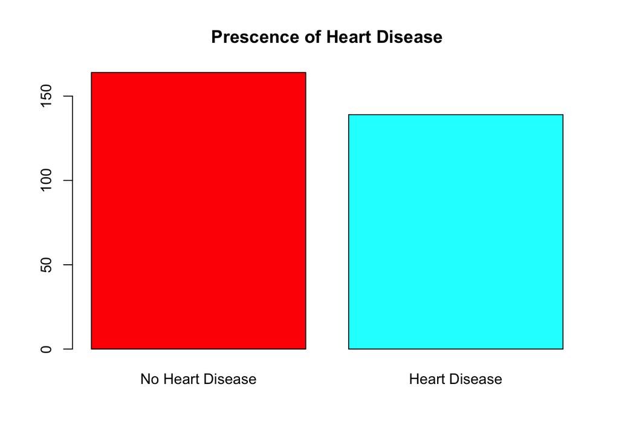

```r
# Graph of our plot to determine how many of our patients potentially have heart disease vs. the one's who are healthy.
barplot(table(heart.data$hd), main = "Prescence of Heart Disease", names.arg=c("No Heart Disease","Heart Disease"),col=rainbow(2))
```

#### Clean up our Data

```r
# change a few predictor variables from integer to factors (make dummies)
change_var <-c("numeric","factor","factor","numeric","numeric","factor","factor","numeric","factor","numeric","factor","factor","factor","factor")
heart.data <- convert.magic(heart.data,change_var)
```

###### Check for missing values - only 6 so just remove them.

```r
# ca and thal have missing values indicated by “?”. Put NA instead.
heart.data$ca <- as.character(heart.data$ca)
heart.data$ca[is.na(heart.data$ca)] <- "0.0"

heart.data$thal <- as.character(heart.data$thal)
heart.data$thal[is.na(heart.data$thal)] <- "3.0"

# ca and thal have missing values indicated by “?”. Put NA instead.
heart.data$ca[heart.data$ca == "?"] <- NA
heart.data$thal[heart.data$thal == "?"] <- NA

s <- sum(is.na(heart.data))
heart.data <- na.omit(heart.data)
#str(heart.data)
```

#### Quick EDA explore Boxplot

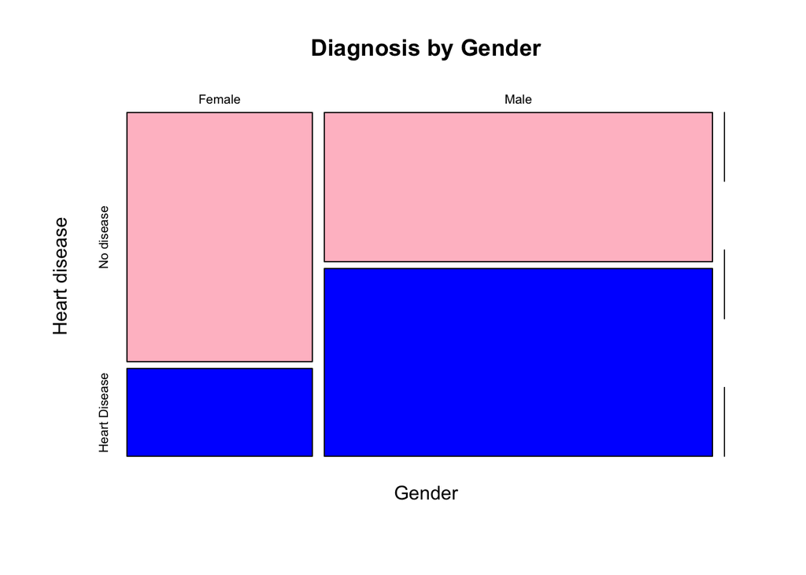

```r
# Create a new dataset that changes some of our variable values in order to plot it cleanly
heart <- heart.data #add labels only for plot
levels(heart$hd) = c("No disease","Heart Disease")
levels(heart$sex) = c("Female","Male","")
mosaicplot(heart$sex ~ heart$hd,
           main="Diagnosis by Gender", shade=FALSE,col=c("pink", "blue"),
           xlab="Gender", ylab="Heart disease")
```

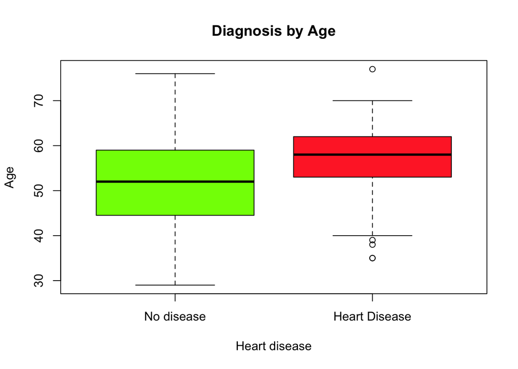

```r
boxplot(heart$age ~ heart$hd,
        main="Diagnosis by Age", col = c("chartreuse1", "firebrick1"),
         ylab="Age",xlab="Heart disease")
```

##### Exploring the Variable’s Correlation

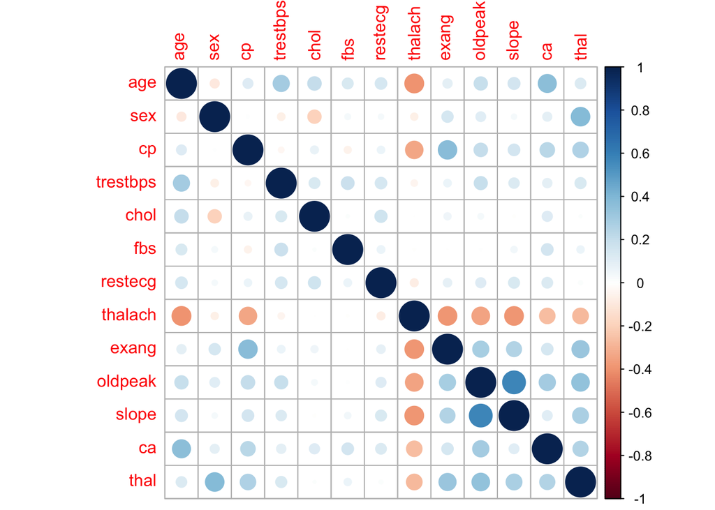

```r
# Check for multicollinearity
heart.cor <- sapply( heart.data, as.numeric )

# Plot our results
corr <- cor(heart.cor[,1:13])
corrplot(corr)
```

Most machine learning algorithms assume that the predictor variables are independent from each others. This the reason why the multicollinearity will be removed to achieve a more robust analysis.

None of our variables seem to be highly correlated with any other. All correlations are less than 0.8.

#### Our “Cleaned Up” Heart Disease Dataset

```r
head(heart.data)
```

```
##   age sex cp trestbps chol fbs restecg thalach exang oldpeak slope  ca thal hd
## 1  63   1  1      145  233   1       2     150     0     2.3     3 0.0  6.0  0
## 2  67   1  4      160  286   0       2     108     1     1.5     2 3.0  3.0  1
## 3  67   1  4      120  229   0       2     129     1     2.6     2 2.0  7.0  1
## 4  37   1  3      130  250   0       0     187     0     3.5     3 0.0  3.0  0
## 5  41   0  2      130  204   0       2     172     0     1.4     1 0.0  3.0  0
## 6  56   1  2      120  236   0       0     178     0     0.8     1 0.0  3.0  0
```

#### Training and testing data for validation

Split the data into Training (70%) and Testing (30%) data. Percentage of heart disease or not must be same in training and testing.

```r
set.seed(10, sample.kind = "Rounding")
split <- createDataPartition(heart.data$hd,p=0.7,list=FALSE)
train <- heart.data[split,]
test <-  heart.data[-split,]
nrow(train)/(nrow(test)+nrow(train)) #checking whether really 70% -> OK
```

```
## [1] 0.7003367
```

### Create a function to caculate accuracy, precision, and f1 scores.

```r
# Function to calculate our accuracy, sensitivity, and f1 scores for our tables.
calculate_stats <- function(table) {
  n = sum(table) # number of instances
  diag = diag(table) # number of correctly classified instances per class
  rowsums = apply(table, 1, sum) # number of instances per class
  colsums = apply(table, 2, sum) # number of predictions per class
  accuracy = sum(diag) / n
  sensitivity = diag / colsums
  precision = diag / rowsums
  f1 = 2 * sensitivity * precision / (sensitivity + precision)
  return(data.frame(accuracy, sensitivity, precision, f1))
}
```

### Predict with 6 different methods with different tuning parameters and compare best model of each method

Results are going to be stored in variable AUC. AUC is the area under the ROC which represents the proportion of positive data points that are correctly considered as positive and the proportion of negative data points that are mistakenly considered as positive. We also store Accuracy which is true positive and true negative divided by all results.

```r
# List to hold our results
AUC = list()
Accuracy = list()
```

### Selecting a model for Logistic Regression

#### Model Selection

##### Forward/Backward Selection

```r
LogReg_model.all <- glm(hd ~ ., data=train, family = 'binomial')
summary(LogReg_model.all)
```

```
##
## Call:
## glm(formula = hd ~ ., family = "binomial", data = train)
##
## Deviance Residuals:
##      Min        1Q    Median        3Q       Max
## -1.96248  -0.41807  -0.09451   0.28136   2.86986
##
## Coefficients:
##              Estimate Std. Error z value Pr(>|z|)
## (Intercept) -2.835079   3.547759  -0.799 0.424222
## age         -0.031809   0.029638  -1.073 0.283157
## sex1         1.852911   0.711217   2.605 0.009180 **
## cp2          0.449824   1.005276   0.447 0.654541
## cp3         -0.514374   0.860555  -0.598 0.550024
## cp4          1.640032   0.868294   1.889 0.058919 .
## trestbps     0.017147   0.015672   1.094 0.273903
## chol         0.003403   0.004919   0.692 0.489080
## fbs1        -0.241553   0.804218  -0.300 0.763905
## restecg2     0.250370   0.492667   0.508 0.611318
## thalach     -0.024926   0.014364  -1.735 0.082682 .
## exang1       0.525959   0.555748   0.946 0.343945
## oldpeak      0.206956   0.284316   0.728 0.466670
## slope2       1.722328   0.616791   2.792 0.005232 **
## slope3       1.037607   1.069302   0.970 0.331867
## ca1.0        2.565178   0.696934   3.681 0.000233 ***
## ca2.0        3.945663   0.994034   3.969 7.21e-05 ***
## ca3.0        2.168612   1.010144   2.147 0.031807 *
## thal6.0     -0.409630   1.003136  -0.408 0.683017
## thal7.0      1.582736   0.549747   2.879 0.003989 **
## ---
## Signif. codes:  0 '***' 0.001 '**' 0.01 '*' 0.05 '.' 0.1 ' ' 1
##
## (Dispersion parameter for binomial family taken to be 1)
##
##     Null deviance: 287.12  on 207  degrees of freedom
## Residual deviance: 121.81  on 188  degrees of freedom
## AIC: 161.81
##
## Number of Fisher Scoring iterations: 6
```

Features for the logistic regression is selected using the stepwise regression. As the basis for feature selection, we will use LogReg_model.all, which is a model that uses all the features. The direction of features selection is backwards, which means features are selected from the available features and uses the AIC criterion.

```r
# Stepwise Regression
LogReg_model.step <- step(LogReg_model.all, direction = 'backward', trace = 0)
variables <- attr(LogReg_model.step$terms, 'term.labels')
summary(LogReg_model.step)
```

```
##
## Call:
## glm(formula = hd ~ sex + cp + thalach + slope + ca + thal, family = "binomial",
##     data = train)
##
## Deviance Residuals:
##      Min        1Q    Median        3Q       Max
## -2.21494  -0.41040  -0.09287   0.37105   2.72922
##
## Coefficients:
##             Estimate Std. Error z value Pr(>|z|)
## (Intercept) -1.48254    2.21313  -0.670  0.50293
## sex1         1.75077    0.65140   2.688  0.00719 **
## cp2         -0.12026    0.90125  -0.133  0.89385
## cp3         -0.91621    0.80959  -1.132  0.25776
## cp4          1.32463    0.77461   1.710  0.08725 .
## thalach     -0.02008    0.01282  -1.567  0.11718
## slope2       1.90287    0.57912   3.286  0.00102 **
## slope3       1.45199    0.89232   1.627  0.10369
## ca1.0        2.31618    0.64071   3.615  0.00030 ***
## ca2.0        3.60523    0.88593   4.069 4.71e-05 ***
## ca3.0        2.04421    0.92732   2.204  0.02749 *
## thal6.0     -0.10528    0.93173  -0.113  0.91003
## thal7.0      1.67747    0.52924   3.170  0.00153 **
## ---
## Signif. codes:  0 '***' 0.001 '**' 0.01 '*' 0.05 '.' 0.1 ' ' 1
##
## (Dispersion parameter for binomial family taken to be 1)
##
##     Null deviance: 287.12  on 207  degrees of freedom
## Residual deviance: 126.49  on 195  degrees of freedom
## AIC: 152.49
##
## Number of Fisher Scoring iterations: 6
```

Out of the 13 features available, 6 features : sex, cp, thalach, slope, ca, thal were chosen

##### We will primarily use the full model with all features.

Because detecting Heart Disease can be a complex diagnosis we also want to analyze with our full set of features. However, this new model can be helpful to predicting heart disease.

### Logistic Regrssion (Using the Full Model)

Our response variable (hd) is binary, so we use logistic regression model to train and predict the dataset. Initially we include all the variables to train and test the model.

```r
set.seed(10, sample.kind = "Rounding")
# Fit a logistic regression model to our data
LogReg_model <- train(hd ~ ., data=train, method = 'glm', family = 'binomial')
summary(LogReg_model)
```

```
##
## Call:
## NULL
##
## Deviance Residuals:
##      Min        1Q    Median        3Q       Max
## -1.96248  -0.41807  -0.09451   0.28136   2.86986
##
## Coefficients: (1 not defined because of singularities)
##              Estimate Std. Error z value Pr(>|z|)
## (Intercept) -2.835079   3.547759  -0.799 0.424222
## age         -0.031809   0.029638  -1.073 0.283157
## sex1         1.852911   0.711217   2.605 0.009180 **
## cp2          0.449824   1.005276   0.447 0.654541
## cp3         -0.514374   0.860555  -0.598 0.550024
## cp4          1.640032   0.868294   1.889 0.058919 .
## trestbps     0.017147   0.015672   1.094 0.273903
## chol         0.003403   0.004919   0.692 0.489080
## fbs1        -0.241553   0.804218  -0.300 0.763905
## restecg1           NA         NA      NA       NA
## restecg2     0.250370   0.492667   0.508 0.611318
## thalach     -0.024926   0.014364  -1.735 0.082682 .
## exang1       0.525959   0.555748   0.946 0.343945
## oldpeak      0.206956   0.284316   0.728 0.466670
## slope2       1.722328   0.616791   2.792 0.005232 **
## slope3       1.037607   1.069302   0.970 0.331867
## ca1.0        2.565178   0.696934   3.681 0.000233 ***
## ca2.0        3.945663   0.994034   3.969 7.21e-05 ***
## ca3.0        2.168612   1.010144   2.147 0.031807 *
## thal6.0     -0.409630   1.003136  -0.408 0.683017
## thal7.0      1.582736   0.549747   2.879 0.003989 **
## ---
## Signif. codes:  0 '***' 0.001 '**' 0.01 '*' 0.05 '.' 0.1 ' ' 1
##
## (Dispersion parameter for binomial family taken to be 1)
##
##     Null deviance: 287.12  on 207  degrees of freedom
## Residual deviance: 121.81  on 188  degrees of freedom
## AIC: 161.81
##
## Number of Fisher Scoring iterations: 6
```

```r
# Fit a prediction and find a confusion matrix
LogReg_pred <- predict(LogReg_model, test)
LogReg_pred.prob <- predict(LogReg_model, test, type='prob')[2]
LogReg_ConfMat <- confusionMatrix(LogReg_pred, test[,"hd"])
LogReg_ConfMat
```

```
## Confusion Matrix and Statistics
##
##           Reference
## Prediction  0  1
##          0 43  7
##          1  5 34
##
##                Accuracy : 0.8652
##                  95% CI : (0.7763, 0.9283)
##     No Information Rate : 0.5393
##     P-Value [Acc > NIR] : 5.93e-11
##
##                   Kappa : 0.7277
##
##  Mcnemar's Test P-Value : 0.7728
##
##             Sensitivity : 0.8958
##             Specificity : 0.8293
##          Pos Pred Value : 0.8600
##          Neg Pred Value : 0.8718
##              Prevalence : 0.5393
##          Detection Rate : 0.4831
##    Detection Prevalence : 0.5618
##       Balanced Accuracy : 0.8626
##
##        'Positive' Class : 0
##
```

```r
# Calculate our The performance of our Modified Model
LogReg_tab <- table(LogReg_pred, test$hd)
calculate_stats(LogReg_tab)
```

```
##    accuracy sensitivity precision       f1
## 0 0.8651685   0.8958333 0.8600000 0.877551
## 1 0.8651685   0.8292683 0.8717949 0.850000
```

```r
#ROC Curve
AUC$logReg <- roc(as.numeric(test$hd),as.numeric(as.matrix((LogReg_pred.prob))))$auc
Accuracy$logReg <- LogReg_ConfMat$overall['Accuracy']
```

#### Logistic Regrssion (Using the Stepwise Model)

Let’s test the predictive power of our Stepwise Model

```r
LogReg_model.step <- glm(hd ~ sex + cp + thalach + slope + ca + thal, family = "binomial", data = train)
summary(LogReg_model.step)
```

```
##
## Call:
## glm(formula = hd ~ sex + cp + thalach + slope + ca + thal, family = "binomial",
##     data = train)
##
## Deviance Residuals:
##      Min        1Q    Median        3Q       Max
## -2.21494  -0.41040  -0.09287   0.37105   2.72922
##
## Coefficients:
##             Estimate Std. Error z value Pr(>|z|)
## (Intercept) -1.48254    2.21313  -0.670  0.50293
## sex1         1.75077    0.65140   2.688  0.00719 **
## cp2         -0.12026    0.90125  -0.133  0.89385
## cp3         -0.91621    0.80959  -1.132  0.25776
## cp4          1.32463    0.77461   1.710  0.08725 .
## thalach     -0.02008    0.01282  -1.567  0.11718
## slope2       1.90287    0.57912   3.286  0.00102 **
## slope3       1.45199    0.89232   1.627  0.10369
## ca1.0        2.31618    0.64071   3.615  0.00030 ***
## ca2.0        3.60523    0.88593   4.069 4.71e-05 ***
## ca3.0        2.04421    0.92732   2.204  0.02749 *
## thal6.0     -0.10528    0.93173  -0.113  0.91003
## thal7.0      1.67747    0.52924   3.170  0.00153 **
## ---
## Signif. codes:  0 '***' 0.001 '**' 0.01 '*' 0.05 '.' 0.1 ' ' 1
##
## (Dispersion parameter for binomial family taken to be 1)
##
##     Null deviance: 287.12  on 207  degrees of freedom
## Residual deviance: 126.49  on 195  degrees of freedom
## AIC: 152.49
##
## Number of Fisher Scoring iterations: 6
```

```r
# Make a prediction on our training set
LogReg_step.prob <- predict(LogReg_model.step, test, type = 'response')
LogReg_step.pred <- ifelse(predict(LogReg_model.step, test, type = 'response') > 0.5, "Yes", "No")
LogReg_step.table <- table(predicted = LogReg_step.pred, actual = test$hd)
LogReg_step.table
```

```
##          actual
## predicted  0  1
##       No  40  9
##       Yes  8 32
```

```r
# Calculate the performance of our Modified Model
stepLogReg.tab <- table(LogReg_step.pred, test$hd)
calculate_stats(stepLogReg.tab)
```

```
##    accuracy sensitivity precision        f1
## 0 0.8089888   0.8333333 0.8163265 0.8247423
## 1 0.8089888   0.7804878 0.8000000 0.7901235
```

Hence, this new stepwise model has lower accuaracy and is not better at predicting the presence or absence of heart disease than the first model.

### Decision Trees

Decision tree algorithms use the training data to segment the predictor space into non-overlapping regions, the nodes of the tree. Each node is described by a set of rules which are then used to predict new responses. The predicted value for each node is the most common response in the node (classification), or mean response in the node (regression).

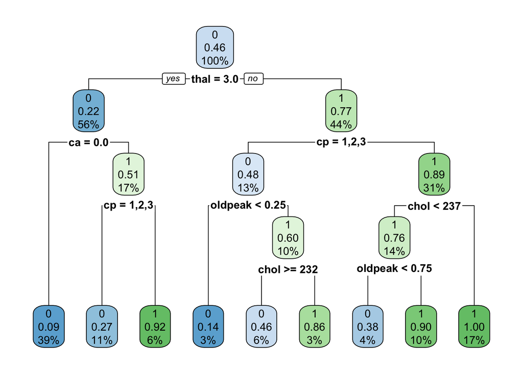

```r
set.seed(10, sample.kind = "Rounding")
# Implementing Decision Tree
Tree_model <- rpart(hd~.,data = train, method = "class" )
# Visual representation of our Tree
rpart.plot(Tree_model)
```

Based off our tree we can see that the most significant variables are Thalassemia the inherited blood disorder that affects the body’s ability to produce hemoglobin and red blood cells (thal), chest pain type (cp), Number of major vessels identified (ca), ST depression induced by exercise (oldpeak), and cholestoral (chol)

```r
# Predict on training set
Tree_pred <- predict(Tree_model, test, type = "class")
Tree_pred.prob <- predict(Tree_model, test, type = "prob")
Tree_ConfMat <- confusionMatrix(Tree_pred, test$hd)
Tree_ConfMat
```

```
## Confusion Matrix and Statistics
##
##           Reference
## Prediction  0  1
##          0 41 15
##          1  7 26
##
##                Accuracy : 0.7528
##                  95% CI : (0.65, 0.8381)
##     No Information Rate : 0.5393
##     P-Value [Acc > NIR] : 2.704e-05
##
##                   Kappa : 0.4954
##
##  Mcnemar's Test P-Value : 0.1356
##
##             Sensitivity : 0.8542
##             Specificity : 0.6341
##          Pos Pred Value : 0.7321
##          Neg Pred Value : 0.7879
##              Prevalence : 0.5393
##          Detection Rate : 0.4607
##    Detection Prevalence : 0.6292
##       Balanced Accuracy : 0.7442
##
##        'Positive' Class : 0
##
```

```r
# ROC Curve for Tree
AUC$tree <- roc(as.numeric(test$hd),as.numeric(as.matrix((Tree_pred))))$auc
Accuracy$tree <- Tree_ConfMat$overall['Accuracy']
```

```r
# Calculate the performance of our Decision Tree Model
calculate_stats(table(Tree_pred, test$hd))
```

```
##   accuracy sensitivity precision        f1
## 0 0.752809   0.8541667 0.7321429 0.7884615
## 1 0.752809   0.6341463 0.7878788 0.7027027
```

### Random Forest

Random forests are about having multiple trees, a forest of trees. Those trees can all be of the same type or algorithm or the forest can be made up of a mixture of tree types (algorithms).

```r
# Generate optimal model
set.seed(10, sample.kind = "Rounding")
RF_model <- randomForest(hd ~ ., data = train, importance = TRUE)
RF_model
```

```
##
## Call:
##  randomForest(formula = hd ~ ., data = train, importance = TRUE)
##                Type of random forest: classification
##                      Number of trees: 500
## No. of variables tried at each split: 3
##
##         OOB estimate of  error rate: 16.35%
## Confusion matrix:
##    0  1 class.error
## 0 99 13   0.1160714
## 1 21 75   0.2187500
```

On average, about two thirds of of each data set is sampled each time a bootstrap sample is taken. With one third of observations remaining, we utilize this subset for testing each newly created tree, creating out-of-bag (OOB) error, with which we can gague the accuracy of each tree.

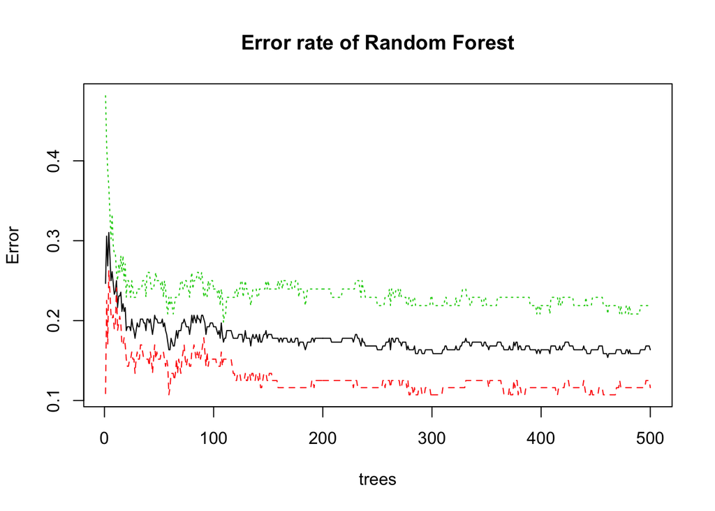

```r
# Plot for the number of trees
plot(RF_model, main = "Error rate of Random Forest")
```

As the number of trees grow the error rate slightly decreases.

```r
# Fit a prediction and find a confusion matrix
RF_pred <- predict(RF_model, test)
RF_pred.prob = predict(RF_model,test,type="prob")[, 2]
RF_ConfMat <- confusionMatrix(RF_pred, test[,"hd"])
RF_ConfMat
```

```
## Confusion Matrix and Statistics
##
##           Reference
## Prediction  0  1
##          0 39  8
##          1  9 33
##
##                Accuracy : 0.809
##                  95% CI : (0.7119, 0.8846)
##     No Information Rate : 0.5393
##     P-Value [Acc > NIR] : 9.657e-08
##
##                   Kappa : 0.6163
##
##  Mcnemar's Test P-Value : 1
##
##             Sensitivity : 0.8125
##             Specificity : 0.8049
##          Pos Pred Value : 0.8298
##          Neg Pred Value : 0.7857
##              Prevalence : 0.5393
##          Detection Rate : 0.4382
##    Detection Prevalence : 0.5281
##       Balanced Accuracy : 0.8087
##
##        'Positive' Class : 0
##
```

```r
# ROCR Curve
AUC$RF <- roc(as.numeric(test$hd),as.numeric(as.matrix((RF_pred.prob))))$auc
Accuracy$RF <- RF_ConfMat$overall['Accuracy']
```

```r
# Calculate the performance of our Random Forests Model
calculate_stats(table(RF_pred, test$hd))
```

```
##    accuracy sensitivity precision        f1
## 0 0.8089888    0.812500 0.8297872 0.8210526
## 1 0.8089888    0.804878 0.7857143 0.7951807
```

### Boosted Trees

```r
set.seed(10, sample.kind = "Rounding")
# Control parameters for model building
objControl <- trainControl(method='cv', number=10,repeats=10, returnResamp = "all")

# Multiplying n.tree by 5 from 10 to 500 for demo purposes
gbmGrid <-  expand.grid(
      interaction.depth = 1:2,
      shrinkage = .1, n.trees = c(10, 50, 100, 500, 1000), n.minobsinnode = 10
    )
```

```r
# Fit a Boosted Model
Boost_model <- train(hd ~ .,data=train, method='gbm', trControl=objControl, tuneGrid = gbmGrid, verbose=F)
Boost_model
```

```
## Stochastic Gradient Boosting
##
## 208 samples
##  13 predictor
##   2 classes: '0', '1'
##
## No pre-processing
## Resampling: Cross-Validated (10 fold)
## Summary of sample sizes: 188, 186, 187, 187, 187, 188, ...
## Resampling results across tuning parameters:
##
##   interaction.depth  n.trees  Accuracy   Kappa
##   1                    10     0.7453463  0.4821445
##   1                    50     0.8272727  0.6500936
##   1                   100     0.8218182  0.6385587
##   1                   500     0.7796320  0.5517551
##   1                  1000     0.7839177  0.5635944
##   2                    10     0.7841558  0.5621884
##   2                    50     0.8367965  0.6693797
##   2                   100     0.8175108  0.6297957
##   2                   500     0.7791558  0.5536748
##   2                  1000     0.7698701  0.5329729
##
## Tuning parameter 'shrinkage' was held constant at a value of 0.1
##
## Tuning parameter 'n.minobsinnode' was held constant at a value of 10
## Accuracy was used to select the optimal model using the largest value.
## The final values used for the model were n.trees = 50, interaction.depth =
##  2, shrinkage = 0.1 and n.minobsinnode = 10.
```

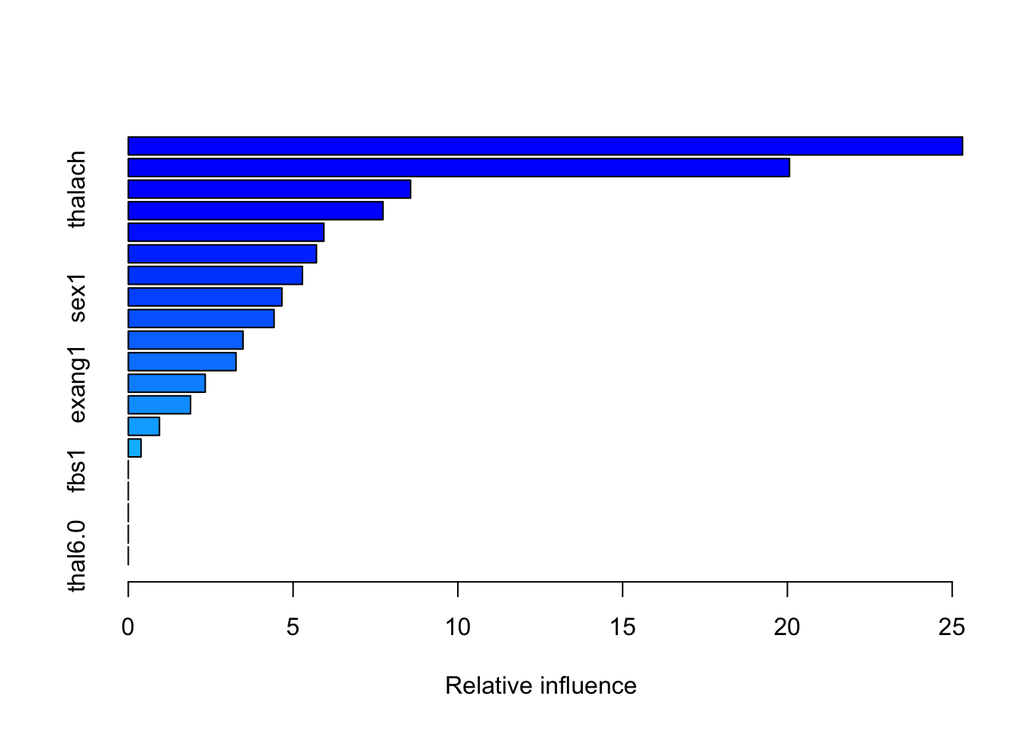

```
##               var    rel.inf
## cp4           cp4 25.3154894
## thal7.0   thal7.0 20.0633469
## thalach   thalach  8.5665760
## oldpeak   oldpeak  7.7295777
## ca2.0       ca2.0  5.9359451
## ca1.0       ca1.0  5.7106517
## age           age  5.2837885
## sex1         sex1  4.6615061
## slope2     slope2  4.4238689
## chol         chol  3.4816554
## trestbps trestbps  3.2690930
## exang1     exang1  2.3358382
## ca3.0       ca3.0  1.8891459
## cp3           cp3  0.9457723
## cp2           cp2  0.3877451
## fbs1         fbs1  0.0000000
## restecg1 restecg1  0.0000000
## restecg2 restecg2  0.0000000
## slope3     slope3  0.0000000
## thal6.0   thal6.0  0.0000000
```

```r
# Summary of the model results with the importance plot of the predictors
summary(Boost_model)
```

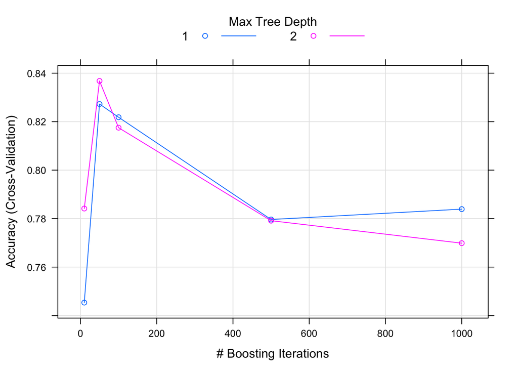

```r
# Check how much the number of trees affect the accuracy of our boosted model.
plot(Boost_model)
```

```r
# Predict the Boosted Tree Model
Boost_pred <- predict(Boost_model, test)
Boost_pred.prob <- predict(Boost_model, test, type='prob')[2]
Boost_ConfMat <- confusionMatrix(Boost_pred, test[,"hd"])
Boost_ConfMat
```

```
## Confusion Matrix and Statistics
##
##           Reference
## Prediction  0  1
##          0 41  9
##          1  7 32
##
##                Accuracy : 0.8202
##                  95% CI : (0.7245, 0.8936)
##     No Information Rate : 0.5393
##     P-Value [Acc > NIR] : 2.567e-08
##
##                   Kappa : 0.6369
##
##  Mcnemar's Test P-Value : 0.8026
##
##             Sensitivity : 0.8542
##             Specificity : 0.7805
##          Pos Pred Value : 0.8200
##          Neg Pred Value : 0.8205
##              Prevalence : 0.5393
##          Detection Rate : 0.4607
##    Detection Prevalence : 0.5618
##       Balanced Accuracy : 0.8173
##
##        'Positive' Class : 0
##
```

```r
# ROCR
AUC$Boost <- roc(as.numeric(test$hd),as.numeric(as.matrix((Boost_pred.prob))))$auc
Accuracy$Boost <- Boost_ConfMat$overall['Accuracy']
```

```r
# Calculate the performance of our Gradient Boosted Model
calculate_stats(table(Boost_pred, test$hd))
```

```
##    accuracy sensitivity precision        f1
## 0 0.8202247   0.8541667 0.8200000 0.8367347
## 1 0.8202247   0.7804878 0.8205128 0.8000000
```

Because our Gradient Boosted Trees has a high Accuracy and Sensitivity we can use this predictive ability to find the importance of each variable in our model.

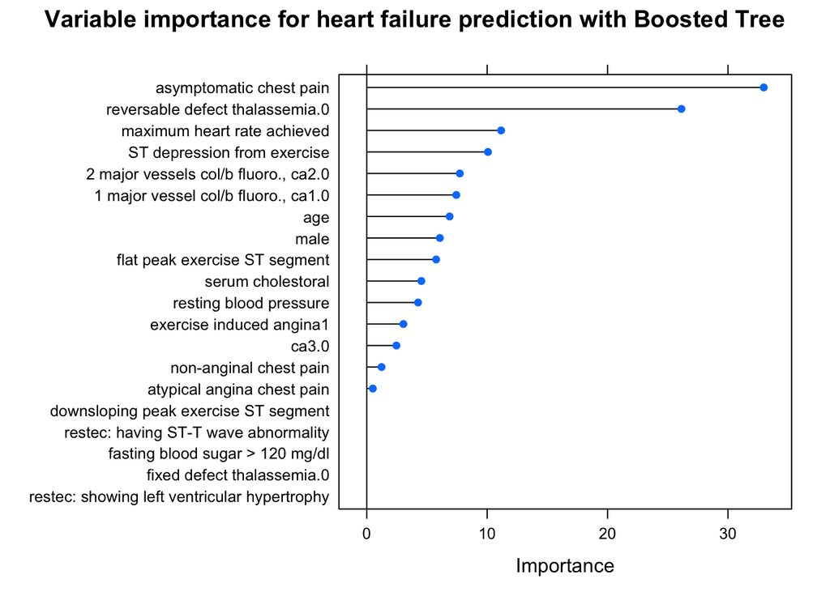

```r
boost_Imp =varImp(Boost_model, scale = FALSE)
row = rownames(varImp(Boost_model, scale = FALSE)$importance)
row = convert.names(row)
rownames(boost_Imp$importance)=row
plot(boost_Imp,main = 'Variable importance for heart failure prediction with Boosted Tree')
```

### Support Vector Machine

Another approach we used to to predict the presense of the heart disease is support vector machines (SVM). SVM divides the dataset into classes with the use of hyperplanes. Below, we used SVM to create a model for our dataset. Additionally, we did k-fold cross validation with 10 folds. We found the best SVM with the tune function.

```r
set.seed(10, sample.kind = "Rounding")
# Reformat our dataframe because SVM requires data to be strictly classification variables
feature.names=names(heart.data)

for (f in feature.names) {
  if (class(heart.data[[f]])=="factor") {
    levels <- unique(c(heart.data[[f]]))
    heart.data[[f]] <- factor(heart.data[[f]],
                   labels=make.names(levels))
  }
}
# Split our data into training sets (70%) and testing sets (30%)
split2 <- createDataPartition(heart.data$hd,p=0.7,list=FALSE)
train2 <- heart.data[split2,]
test2 <-  heart.data[-split2,]
```

When the cost argument is small, then the margins will be wide and many support vectors will be on the margin or will violate the margin. When the cost argument is large, then the margins will be narrow and there will be few support vectors on the margin or violating the margin.

```r
# Control parameters for model building
fitControl <- trainControl(method = "cv", number = 10,
                           repeats = 3, # number is number of iteration, repeat the cross validation
                           # Estimate class probabilities
                           classProbs = TRUE,
                           returnResamp = "all",
                           # Evaluate performance using the following function
                           summaryFunction = twoClassSummary)

# Fit the Support Vector Machine model
SVM_model <- train(hd ~ ., data = train2, method = "svmLinear2", trControl = fitControl, preProcess = c("center", "scale"),
                  tuneLength = 10, tuneGrid = data.frame(cost = c(.1, .25, .5, .75, 1, 2)), metric = "ROC")
SVM_model
```

```
## Support Vector Machines with Linear Kernel
##
## 208 samples
##  13 predictor
##   2 classes: 'X1', 'X2'
##
## Pre-processing: centered (20), scaled (20)
## Resampling: Cross-Validated (10 fold)
## Summary of sample sizes: 187, 187, 188, 187, 188, 186, ...
## Resampling results across tuning parameters:
##
##   cost  ROC        Sens       Spec
##   0.10  0.9063805  0.8659091  0.8100000
##   0.25  0.9090909  0.8659091  0.7888889
##   0.50  0.9053451  0.8659091  0.7888889
##   0.75  0.9026178  0.8659091  0.7777778
##   1.00  0.9025000  0.8659091  0.7777778
##   2.00  0.9016751  0.8477273  0.7900000
##
## ROC was used to select the optimal model using the largest value.
## The final value used for the model was cost = 0.25.
```

```r
summary(SVM_model)
```

```
##
## Call:
## svm.default(x = as.matrix(x), y = y, kernel = "linear", cost = param$cost,
##     probability = classProbs)
##
##
## Parameters:
##    SVM-Type:  C-classification
##  SVM-Kernel:  linear
##        cost:  0.25
##
## Number of Support Vectors:  80
##
##  ( 39 41 )
##
##
## Number of Classes:  2
##
## Levels:
##  X1 X2
```

80 support vectors with 39 in the first class, and 41 in the second class.

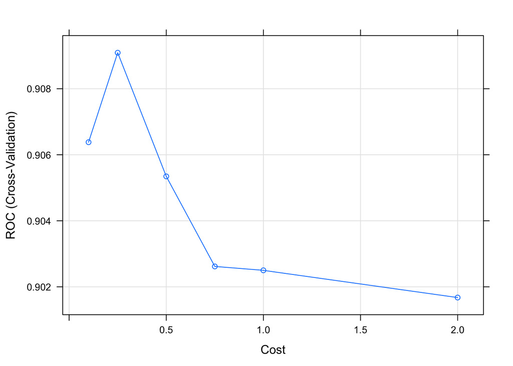

```r
# Plot the SVM model
plot(SVM_model)
```

We can see that the optimal cost for our SVM model is C = 0.25

```r
# Predict the Support Vector Machine model
SVM_pred <- predict(SVM_model, test2)
SVM_pred.prob <- predict(SVM_model, test2, type='prob')[2]
SVM_ConfMat <- confusionMatrix(SVM_pred, test2[,"hd"])
SVM_ConfMat
```

```
## Confusion Matrix and Statistics
##
##           Reference
## Prediction X1 X2
##         X1 40  7
##         X2  8 34
##
##                Accuracy : 0.8315
##                  95% CI : (0.7373, 0.9025)
##     No Information Rate : 0.5393
##     P-Value [Acc > NIR] : 6.345e-09
##
##                   Kappa : 0.6614
##
##  Mcnemar's Test P-Value : 1
##
##             Sensitivity : 0.8333
##             Specificity : 0.8293
##          Pos Pred Value : 0.8511
##          Neg Pred Value : 0.8095
##              Prevalence : 0.5393
##          Detection Rate : 0.4494
##    Detection Prevalence : 0.5281
##       Balanced Accuracy : 0.8313
##
##        'Positive' Class : X1
##
```

```r
#ROC Curve
AUC$svm <- roc(as.numeric(test2$hd),as.numeric(as.matrix((SVM_pred.prob))))$auc
Accuracy$svm <- SVM_ConfMat$overall['Accuracy']
```

```r
# Calculate the performance of our Support Vector Machine Model
calculate_stats(table(SVM_pred, test2$hd))
```

```
##     accuracy sensitivity precision        f1
## X1 0.8314607   0.8333333 0.8510638 0.8421053
## X2 0.8314607   0.8292683 0.8095238 0.8192771
```

### K-Nearest Neighbor (KNN)

K Nearest Neighbors is a simple algorithm but works incredibly in practice that stores all the available cases and classifies the new data or case based on a similarity measure. It suggests that if the new point added to the sample is similar to the neighbor points, that point will belong to the particular class of the neighbor points.

```r
set.seed(10, sample.kind = "Rounding")
# Control parameters for model building
x = trainControl(method = "cv",
                 number = 10,
                 returnResamp = "all",
                 repeats = 3,
                 classProbs = TRUE,
                 summaryFunction = twoClassSummary)

# Fit a K- Nearest Neighbors Model
KNN_model = train(hd~. , data = train2, method = "knn",
               preProcess = c("center","scale"),
               trControl = x,
               metric = "ROC",
               tuneLength = 10)

# print model results
print(KNN_model)
```

```
## k-Nearest Neighbors
##
## 208 samples
##  13 predictor
##   2 classes: 'X1', 'X2'
##
## Pre-processing: centered (20), scaled (20)
## Resampling: Cross-Validated (10 fold)
## Summary of sample sizes: 188, 186, 187, 187, 187, 188, ...
## Resampling results across tuning parameters:
##
##   k   ROC        Sens       Spec
##    5  0.8831061  0.8833333  0.7477778
##    7  0.8849327  0.8825758  0.7711111
##    9  0.8814015  0.8734848  0.7800000
##   11  0.8817340  0.8916667  0.7722222
##   13  0.8835943  0.9007576  0.7711111
##   15  0.8894108  0.8833333  0.7622222
##   17  0.8932955  0.8833333  0.7811111
##   19  0.8934091  0.8833333  0.7611111
##   21  0.9001894  0.9015152  0.7611111
##   23  0.9029293  0.8924242  0.7611111
##
## ROC was used to select the optimal model using the largest value.
## The final value used for the model was k = 23.
```

In general, KNN algorithm uses in search applications where people looking for similar items. K in the KNN algorithm denotes the number of nearest neighbors of the new point which needed to be predicted.

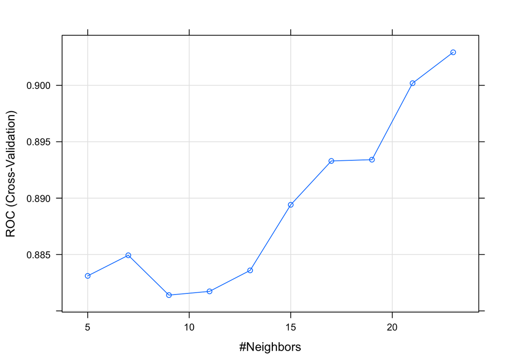

```r
# Plot how the Number of Neighbors affect the ROC
plot(KNN_model)
```

We can see that as the number of neighbors k = 23 the ROCR increases.

```r
# Predict the KNN model
KNN_pred <- predict(KNN_model, test2)
KNN_pred.prob <- predict(KNN_model, test2, type = "prob")[,2]
KNN_ConfMat <- confusionMatrix(KNN_pred, test2[,"hd"])
KNN_ConfMat
```

```
## Confusion Matrix and Statistics
##
##           Reference
## Prediction X1 X2
##         X1 40 10
##         X2  8 31
##
##                Accuracy : 0.7978
##                  95% CI : (0.6993, 0.8755)
##     No Information Rate : 0.5393
##     P-Value [Acc > NIR] : 3.388e-07
##
##                   Kappa : 0.5915
##
##  Mcnemar's Test P-Value : 0.8137
##
##             Sensitivity : 0.8333
##             Specificity : 0.7561
##          Pos Pred Value : 0.8000
##          Neg Pred Value : 0.7949
##              Prevalence : 0.5393
##          Detection Rate : 0.4494
##    Detection Prevalence : 0.5618
##       Balanced Accuracy : 0.7947
##
##        'Positive' Class : X1
##
```

```r
# Calculate the performance of our K-Nearest Neighbors Model
calculate_stats(table(KNN_pred, test2$hd))
```

```
##     accuracy sensitivity precision        f1
## X1 0.7977528   0.8333333 0.8000000 0.8163265
## X2 0.7977528   0.7560976 0.7948718 0.7750000
```

```r
#ROC Curve
AUC$knn <- roc(as.numeric(test2$hd),as.numeric(as.matrix((KNN_pred.prob))))$auc
Accuracy$knn <- KNN_ConfMat$overall['Accuracy']
```

#### Plot the ROC curves for our various models

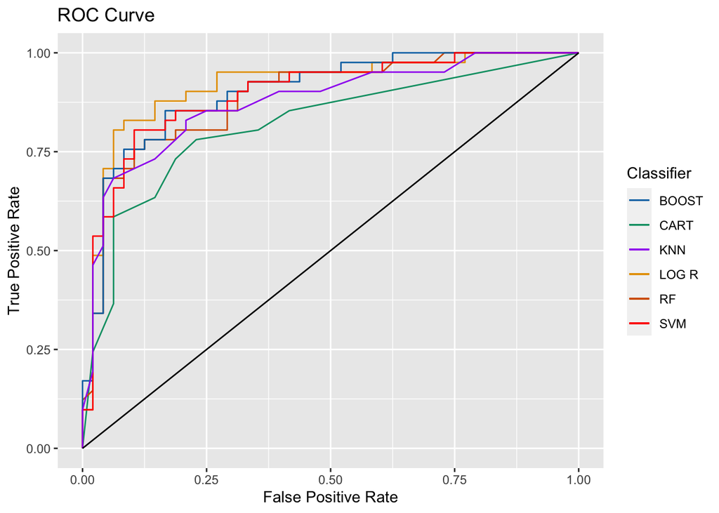

```r
# create a prediction object
pr <- ROCR::prediction(LogReg_pred.prob, test$hd)
prf <- performance(pr, measure = "tpr", x.measure = "fpr")

# create a data frame for TP and FP rates
dd1 <- data.frame(FP = prf@x.values[[1]], TP = prf@y.values[[1]])

# CART
pr2 <- ROCR::prediction(Tree_pred.prob[,2], test$hd)
prf2 <- performance(pr2, measure = "tpr", x.measure = "fpr")
dd2 <- data.frame(FP = prf2@x.values[[1]], TP = prf2@y.values[[1]])

# RF
pr3 <- ROCR::prediction(RF_pred.prob, test$hd)
prf3 <- performance(pr3, measure = "tpr", x.measure = "fpr")
dd3 <- data.frame(FP = prf3@x.values[[1]], TP = prf3@y.values[[1]])

# BOOST
pr4 <- ROCR::prediction(Boost_pred.prob, test$hd)
prf4 <- performance(pr4, measure = "tpr", x.measure = "fpr")
dd4 <- data.frame(FP = prf4@x.values[[1]], TP = prf4@y.values[[1]])

# SVM
pr5 <- ROCR::prediction(SVM_pred.prob, test2$hd)
prf5 <- performance(pr5, measure = "tpr", x.measure = "fpr")
dd5 <- data.frame(FP = prf5@x.values[[1]], TP = prf5@y.values[[1]])

# KNN
pr6 <- ROCR::prediction(KNN_pred.prob, test2$hd)
prf6 <- performance(pr6, measure = "tpr", x.measure = "fpr")
dd6 <- data.frame(FP = prf6@x.values[[1]], TP = prf6@y.values[[1]])

# plot ROC curve for logistic regression
g <- ggplot() +
  geom_line(data = dd1, aes(x = FP, y = TP, color = 'LOG R')) +
  geom_line(data = dd2, aes(x = FP, y = TP, color = 'CART')) +
  geom_line(data = dd3, aes(x = FP, y = TP, color = 'RF')) +
  geom_line(data = dd4, aes(x = FP, y = TP, color = 'BOOST')) +
  geom_line(data = dd5, aes(x = FP, y = TP, color = 'SVM')) +
  geom_line(data = dd6, aes(x = FP, y = TP, color = 'KNN')) +
  geom_segment(aes(x = 0, xend = 1, y = 0, yend = 1)) +
  scale_y_continuous(limits=c(0,1)) +
  scale_x_continuous(limits=c(0,1)) +
  ggtitle('ROC Curve') +
  labs(x = 'False Positive Rate', y = 'True Positive Rate')

g + scale_colour_manual(name = 'Classifier', values = c('LOG R'='#E69F00', 'CART'='#009E73', 'RF'='#D55E00', 'BOOST'='#0072B2', 'SVM' = 'red' , 'KNN' = 'purple' ))
```

```r
# The AUC for each of our models using the ROC curve.
auc <- rbind(performance(pr, measure = 'auc')@y.values[[1]],
             performance(pr2, measure = 'auc')@y.values[[1]],
             performance(pr3, measure = 'auc')@y.values[[1]],
             performance(pr4, measure = 'auc')@y.values[[1]],
             performance(pr5, measure = 'auc')@y.values[[1]],
             performance(pr6, measure = 'auc')@y.values[[1]])
rownames(auc) <- (c('LOG R', 'CART', 'RF', "BOOST", "SVM", "KNN"))
colnames(auc) <- 'Area Under ROC Curve'
round(auc, 4)
```

```
##       Area Under ROC Curve
## LOG R               0.9162
## CART                0.8176
## RF                  0.8869
## BOOST               0.9009
## SVM                 0.8958
## KNN                 0.8753
```

## Conclusion

We can see that Logistic Regression and Boosted Trees perform the best when it comes to predicting Heart Disease. While Decision Tree performs the worst due to the fact that it’s a weaker classification model.

Using these models we can see that the variables that best predict the presecence of Heart Disease in patients are: Thalassemia the inherited blood disorder that affects the body’s ability to produce hemoglobin and red blood cells (thal), chest pain type (cp).